# Unit 9 Pre-Live Session

Johnny Vogt

## Discussion 1: Error Metrics

Consider the following confusion matrix computed from a validation set. The “yes” outcome here is whether a person commits to purchasing an item over the phone (advertising).

```
##         TrueNo TrueYes
## PredNo    6326     120
## PredYes   1638     958
```

1. Compute by hand the sensitivity and specificity for the confusion matrix assuming “yes” is the positive class.

Sensitivity = TY/(TY + PY) = 958/(958 +120) = 958/1078 = 0.889

2. Compute by hand the negative and positive predictive values.

Positive Predictive Value = TP/( TP + PY (False Positve)) = 958/(958+1638) = 958/2596 = 0.369

Negative Predictive Value = TN/(TN + PN (False Negative)) = 6326/(6326 + 120) = 6326/6446 = 0.981

3. What percentage of the entire validation set made a purchase?

True Yes = 120 + 958 = 1078 Total Sample = 6326 + 1638 + 120 + 958 =9042

4. Suppose the company has a list of 1000 potential new customers with which the model (with performance metrics you computed earlier) can be applied. Suppose that 300 of these 1000 were predicted that they would make a purchase. How many customers of these 300 that you predicted as “yes” will actually be a “yes”? Which one of the previous metrics you calculated tells you this?

300 * 0.369 = 110.7

5. (Something to chew on) Suppose that, for every sale, the company makes a profit of 200 dollars and it costs them 20 dollars for every unsuccessful sales pitch. They lose out on 200 dollars if they didn’t identify a customer that would say “yes” to the campaign. They lose 0 dollars for those they didn’t call and would have said “no” to begin with. What do you think the expected net profit (after dealing with the cost) is when considering making the sales pitch to the 1000 prospective clients? What is the expected profit lossed (or missed) under this scenario? Make whatever assumptions you need to come up with your answer, just state those assumptions along with your answer.

False Positives: 300 - 111 = 189 Expected Buyers: 0.119 * 1000 = 119 False Negatives: 119-111 = 8

Calcuating munnies Successfull Sale: 111 * 200 = $22200 Unseccessful call: 189 * -20 = $-3780 Missed Sale: 8 * -200 = $-1600

net Profit: 22200 - 3780 - 1600 = $16,820

## LDA Assumptions.

Consider the following simulated data sets. Based on what you got out of the videos, for each data set comment on whether you think a discriminant analysis tool would be appropriate and if so would it be better to fit an LDA or QDA model.

1st Dataset : No Discriminate analysis tool would work well, very complex 2nd Dataset: LDA 3rd Dataset: QDA

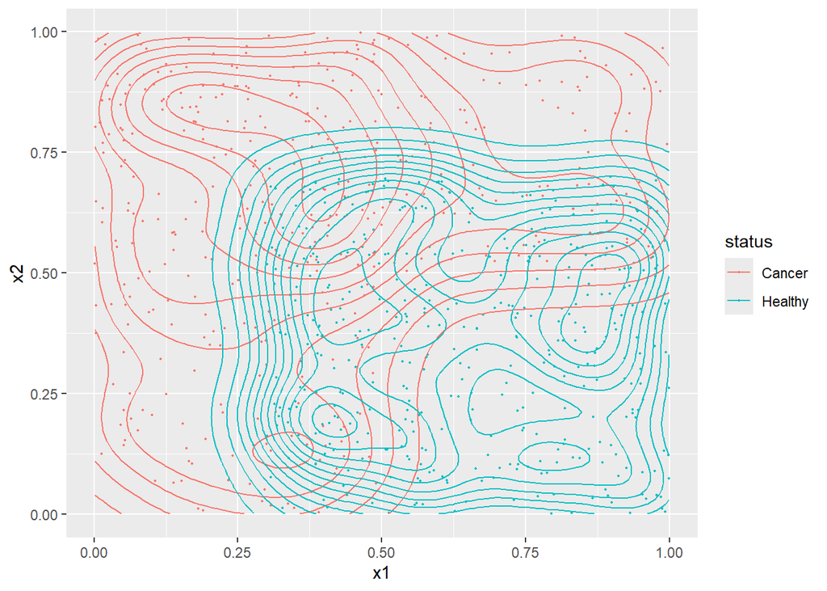

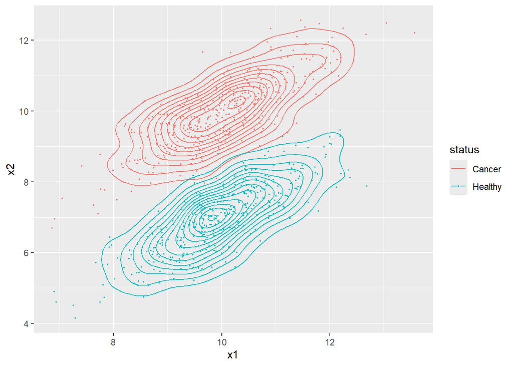

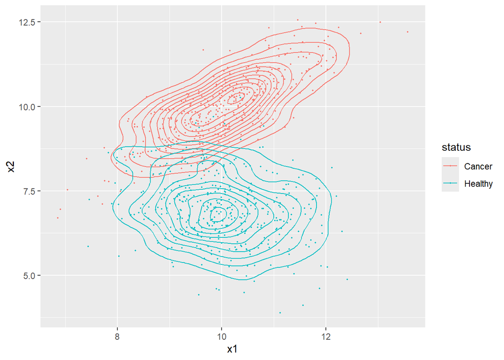

## Discussion 2: Confusion Matrix Sanity Checks

It is quite common for people to read confusion matrix results without paying enough attention to the details, in particular, what you want as output versus what **R** actually gives. Using one of the previous data sets from the second discussion, consider we added multiple columns that defined the response variable using different strategies. The first is recoding Healthy and Cancer as 0 and 1, respectively. The second is recoding as Control and Sick. In all 3 settings the “positive” class is viewed as the Cancer group.

```r
full2$status2<-ifelse(full2$status=="Healthy",0,1)
full2$status3<-factor(ifelse(full2$status=="Healthy","Control","Sick"))
head(full2)
```

```
##         x1        x2 status status2 status3
## 1  9.24283  8.466924 Cancer       1    Sick
## 2 10.25176 10.274625 Cancer       1    Sick
## 3 11.16205 10.895535 Cancer       1    Sick
## 4  8.05908  7.490272 Cancer       1    Sick
## 5 10.27510 10.539110 Cancer       1    Sick
## 6 10.43156 10.528610 Cancer       1    Sick
```

The following code runs an LDA model on the data and produces the confusion matrix on the training data itself. This is done a number of times using slightly different sets of code. Compare the resulting confusion matrices and summarize what is going on with the code and options. Please note that the CV part of the code and error metric is irrelevant here because LDA doesn’t have any tuning parameters.

```r
fitControl<-trainControl(method="repeatedcv",number=5,repeats=1,classProbs=TRUE, summaryFunction=mnLogLoss)
set.seed(1234)

#Version 1
lda.fit<-train(status~x1+x2,
               data=full2,
               method="lda",
               trControl=fitControl,
               metric="logLoss")

#Computing predicted probabilities on the training data
predictions <- predict(lda.fit, full2, type = "prob")[,"Cancer"]

#Getting confusion matrix
threshold=0.5
lda.preds<-factor(ifelse(predictions>threshold,"Cancer","Healthy"),levels=c("Cancer","Healthy"))
confusionMatrix(data = lda.preds, reference = full2$status)




#Version2
lda.fit<-train(status3~x1+x2,
               data=full2,
               method="lda",
               trControl=fitControl,
               metric="logLoss")

#Computing predicted probabilities on the training data
predictions <- predict(lda.fit, full2, type = "prob")[,"Sick"]

#Getting confusion matrix
threshold=0.5
lda.preds<-factor(ifelse(predictions>threshold,"Sick","Control"),levels=c("Sick","Control"))
confusionMatrix(data = lda.preds, reference = full2$status3)


#Version3
lda.fit<-train(status3~x1+x2,
               data=full2,
               method="lda",
               trControl=fitControl,
               metric="logLoss")

#Computing predicted probabilities on the training data
predictions <- predict(lda.fit, full2, type = "prob")[,"Sick"]

#Getting confusion matrix
threshold=0.5
lda.preds<-factor(ifelse(predictions>threshold,"Sick","Control"))
confusionMatrix(data = lda.preds, reference = full2$status3)




#Version 4
lda.fit<-train(status3~x1+x2,
               data=full2,
               method="lda",
               trControl=fitControl,
               metric="logLoss")

#Computing predicted probabilities on the training data
predictions <- predict(lda.fit, full2, type = "prob")[,"Sick"]

#Getting confusion matrix
threshold=0.5
lda.preds<-factor(ifelse(predictions>threshold,"Sick","Control"))
confusionMatrix(data = lda.preds, reference = full2$status3,positive="Sick")



#Version 5
lda.fit<-train(status3~x1+x2,
               data=full2,
               method="lda",
               trControl=fitControl,
               metric="logLoss")

#Computing predicted probabilities on the training data
predictions <- predict(lda.fit, full2, type = "raw")
head(predictions)

confusionMatrix(data = predictions, reference = full2$status3)



#knn.preds<-factor(ifelse(predictions$knn>threshold,"Cancer","Healthy"),levels=c("Cancer","Healthy"))
#confusionMatrix(data = knn.preds, reference = validate$status)
```

[output not shown]